# '고등교육이 경제에 미치는 영향에 대해 회귀예측' 보고서

## 1. 배경

고등교육은 경제사회 발전의 중요한 버팀목이며, 발달한 고등교육은 발달한 경제사회를 조력할 수 있다. 1980년데부터, 중국에서 교육과 경제의 상관관계에 대해 연구하는 학자를 있게 되었고 점차 고등교육의 영역에 집중되었다. 요즘에는 중국에서 정부나 사회의 고둥교육에 대한 중시 정도는 갈수록 높아지고 있다. 그리고 정부 고등교육에 대해 재정지출도 해마다 증가하고 있다. 그래서 최근 몇 년간에 중국에서 빠르게 발전하고 있는 6개 도시를 골랐고 고등교육과 경제발전의 상관관계를 연구하려고 한다.

## 2. 데이터과 모형

중국에서 New First-tier Cities라는 best list가 있다. 이 best list는 중국 337개 지방 이상 도시의 순위를 매겨 상위 15개 도시를 선정한다. 그리고 이 list는 해마다 다시 선정할 것이다. 저는 2017년부터 2019년까지 리스트에 계속 올라있는 6개 도시를 뽑아서 분석하겠다.

[figure not shown]

중국은 2002년부터 고등교육은 대중화 단계로 진입하는 자료가 있고 2003년부터 안정적인 증가를 유지하고 있다고 한다. 그래서 저는 2003년부터 2014년까지의 데이터로 사용하여 예측모형을 도출하고 2015년~2019년의 데이터를 예측하려고 한다.

### 2.1 Data Description

선택한 6개 도시가 바로 난징시(NanJing), 칭다오시(QingDao), 총칭시(ChongQing), 우한시(WuHan), 청두시(ChengDu), 정주시(ZhengZhou)이다. 각 도시의 GDP는 경제지포로 설정하고 정부교육 지출, 재학학생 수, 교직원 수, 특허 권한량의 데이터를 찾아서 4가지 변수로 고등교육의 수준으로 지정했다.

```python
import os
import pandas as pd
from sklearn import linear_model
from sklearn.model_selection import cross_val_score
import numpy as np
```

```python
os.getcwd()
df = pd.read_excel('data3.xlsx')
print(df.head())
```

```
   year  njln_gdp  njln_edu     njt    njs     njp  qdln_gdp  qdln_edu  \
0  2003  7.281427  2.785153  2.1513  33.36  0.1552  6.813509  2.499951
1  2004  7.471499  2.963349  2.6051  49.15  0.1761  7.020685  2.629086
2  2005  7.712028  3.101290  2.8961  50.37  0.2166  7.294631  2.929309
3  2006  7.847372  3.259396  3.4268  62.08  0.2847  7.486629  3.131220
4  2007  8.011594  3.721763  4.0769  60.88  0.3778  7.667867  3.501953

      qdt      qds  ...  cdln_gdp  cdln_edu     cdt      cds     cdp  \
0  1.0293  16.8439  ...  7.042544  2.185062  1.8159  23.6300  0.2178
1  1.2347  20.1739  ...  7.208625  2.319059  2.4329  27.7510  0.2636
2  1.3894  23.9761  ...  7.324922  2.387799  2.7591  30.2874  0.3079
3  1.5195  26.0339  ...  7.561894  2.632112  3.2733  38.0230  0.5133
4  1.6005  26.4917  ...  7.645849  3.117317  3.4655  49.6281  0.7239

   zzln_gdp  zzln_edu     zzt    zzs     zzp
0  6.273028  1.840534  1.2848  25.65  0.2636
1  6.507293  1.999329  1.7422  32.46  0.1559
2  6.619219  2.385602  1.9031  37.35  0.1761
3  6.786514  2.681501  2.2062  41.81  0.2178
4  6.932916  3.250731  2.4803  46.45  0.2847

[5 rows x 31 columns]
```

### 2.2 모형설정

$$Y=b_0+b_1X_1+b_2X_2+b_3X_3$$

$$X_1$$

는 정부교육지출이고 $$X_2$$ 는 재학학생 수이고 $$X_3$$ 는 특허 권한량이다.

## 3. 회귀예측

### 3.1 선형의합도

정부교육 지출과 각 도시의 GDP의 데이터를 아주 크니까 예측의 편의적을 위하여 log를 했다. 회귀분석의 결과를 보면 정부교육지출과 GDP의 상관성이 제일 높으니까 우선 각 도시의 정부교육 지출과 GDP의 선형의합도를 만들었다.

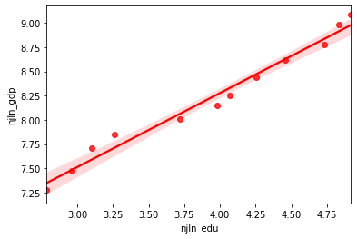

```python
import seaborn as sns
%matplotlib inline
sns.regplot(x='njln_edu',y='njln_gdp',data=df,color='red')
```

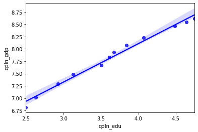

```python
sns.regplot(x='qdln_edu',y='qdln_gdp',data=df,color='blue')
```

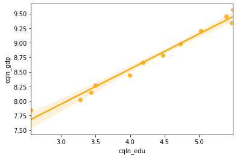

```python
sns.regplot(x='cqln_edu', y='cqln_gdp',data=df,color='orange')
```

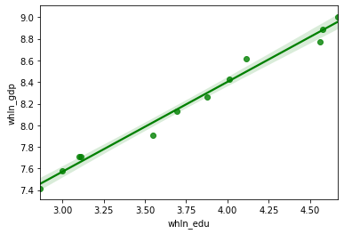

```python
sns.regplot(x='whln_edu', y='whln_gdp',data=df,color='green')
```

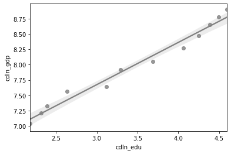

```python
sns.regplot(x='cdln_edu', y='cdln_gdp',data=df,color='gray')
```

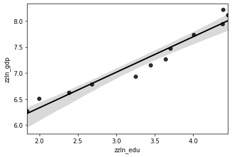

```python
sns.regplot(x='zzln_edu', y='zzln_gdp',data=df,color='black')
```

### 3.2 변량 상관성의 측정

교직원 수변량을 추가하면 오차가 크다. 그리고 회귀분석으로 보면 이 변량은 현정하지 않다.

[figure not shown]

위에 그림을 보니까 교직월 수이라는 변량은 모형에 적용하지 않다고 생각하고 일단 지웠다. 그래서 정부교육지출, 재학학생 수, 특허권한량3가지 변량을 사요하여 각 도시의 예측모형을 완성되었다. 모형에 따라 2015-2019년 GDP를 예측한다.

### 3.3 각 도시에 대한 예측과 비교

저는 각 도시의 2003년부터 2014년 까지의 데이터를 사용해서 예측모형을 완성하고 2015년부터 2019년까지 5년간의 GDP를 예측했다. 그리고 예측되었던 결과는 인터넷에서 찾았던 실질 데이터로 그림을 만들고 비교할 것이다. 아래 모던 예측 그림 중에 빨간 곡선이 예측된 GDP이고 파란색 곡선이 그 도시 실질 GDP이다.

#### 3.3.1 난징시에 대한 예측과 비교

```
6.10289761331522 [0.31534521 0.00923712 0.30503418]
0.006922827299499867
         x1     x2      x3
0  5.182738  81.26  2.8104
1  5.312516  82.78  2.8782
2  5.383770  84.08  3.2073
3  5.533639  85.17  4.4081
4  5.666600  87.78  5.5004
           y
0   9.345126
1   9.420772
2   9.555637
3   9.979251
4  10.378477
<class 'pandas.core.frame.DataFrame'>
         x1     x2      x3          y
0  5.182738  81.26  2.8104   9.345126
1  5.312516  82.78  2.8782   9.420772
2  5.383770  84.08  3.2073   9.555637
3  5.533639  85.17  4.4081   9.979251
4  5.666600  87.78  5.5004  10.378477
```

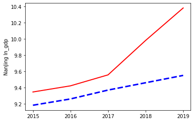

```python
lm=linear_model.LinearRegression()
features1=['njln_edu','njs','njp']
X1 = df[features1]
y1 = df['njln_gdp']
model = lm.fit(X1,y1)
print(model.intercept_, model.coef_)

scores = - cross_val_score(lm, X1, y1, cv=5, scoring='neg_mean_squared_error')
print(np.mean(scores))

list1=[[5.182738,81.26,2.8104],[5.312516,82.78,2.8782],[5.38377,84.08,3.2073],[5.533639,85.17,4.4081],[5.6666,87.78,5.5004]]
pred_x = pd.DataFrame(list1, columns = ['x1','x2','x3'])
print(pred_x)
pred_y = pd.DataFrame(lm.predict(pred_x), columns = ['y'])
print(pred_y)
print(type(pred_y))

result = pd.concat([pred_x, pred_y], axis = 1)
print(result)
import matplotlib.pyplot as plt
x_data = ['2015','2016','2017','2018','2019']
y_pred1 = [9.345126,9.420772,9.555637,9.979251,10.378477]
y_data1 = [9.18202,9.259418,9.368634,9.458793,9.549025]

plt.plot(x_data,y_pred1,color='red',linewidth=2.0,linestyle='-')
plt.plot(x_data,y_data1,color='blue',linewidth=3.0,linestyle='--')
plt.ylabel('NanJing ln_gdp')
plt.show()
```

결과를 따라 난징시에 대한 예측모형은 $$Y_{nj}=6.103+0.315X_1+0.009X_2+0.305X_3$$

그리고 그림을 보면 2015부터 2017년의 예측은 0.2정도 오차가 있고 2017년 부터 오차가 점차 크지고 있다.

#### 3.3.2 칭다오시에 대한 예측과 비교

```
4.6786353700467 [ 0.65432959  0.03029912 -0.05047278]
0.008516584405302719
         x1       x2      x3
0  4.948158  32.2260  2.0168
1  5.053243  34.0875  2.2046
2  5.223054  34.6328  2.3870
3  5.289284  39.7982  2.2521
4  5.334661  41.5824  3.8737
          y
0  8.790988
1  8.906671
2  9.025099
3  9.231751
4  9.233656
<class 'pandas.core.frame.DataFrame'>
         x1       x2      x3         y
0  4.948158  32.2260  2.0168  8.790988
1  5.053243  34.0875  2.2046  8.906671
2  5.223054  34.6328  2.3870  9.025099
3  5.289284  39.7982  2.2521  9.231751
4  5.334661  41.5824  3.8737  9.233656
```

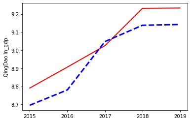

```python
features2=['qdln_edu','qds','qdp']
X2 = df[features2]
y2 = df['qdln_gdp']
model = lm.fit(X2,y2)
print(model.intercept_, model.coef_)
scores = - cross_val_score(lm, X2, y2, cv=5, scoring='neg_mean_squared_error')
print(np.mean(scores))
##예측
list2=[[4.948158,32.226,2.0168],[5.053243,34.0875,2.2046],[5.223054,34.6328,2.387],[5.289284,39.7982,2.2521],[5.334661,41.5824,3.8737]]
pred_x = pd.DataFrame(list2, columns = ['x1','x2','x3'])
print(pred_x)
pred_y = pd.DataFrame(lm.predict(pred_x), columns = ['y'])
print(pred_y)
print(type(pred_y))
result = pd.concat([pred_x, pred_y], axis = 1)
print(result)
##비교
import matplotlib.pyplot as plt
x_data = ['2015','2016','2017','2018','2019']
y_pred2 = [8.790988,8.906671,9.025099,9.231751,9.233656]
y_data2 = [8.695691,8.780474,9.047719,9.13809,9.142489]

plt.plot(x_data,y_pred2,color='red',linewidth=2.0,linestyle='-')
plt.plot(x_data,y_data2,color='blue',linewidth=3.0,linestyle='--')
plt.ylabel('QingDao ln_gdp')
plt.show()
```

위에 그림을 보면 예측결과가 괜찮고 거의 다 0.1정도 오차범위 안에 control를 했다.

#### 3.3.3충칭시에 대한 예측과 비교

```
6.819454517708268 [0.19426497 0.02041108 0.06875515]
0.0018825236018483464
         x1       x2      x3
0  5.679398  76.7114  3.8914
1  5.858930  73.2475  4.2738
2  5.955060  80.5208  3.4780
3  6.038317  82.7945  4.5688
4  6.108843  90.7426  4.3807
           y
0   9.756079
1   9.746546
2   9.858961
3   9.996542
4  10.159539
<class 'pandas.core.frame.DataFrame'>
         x1       x2      x3          y
0  5.679398  76.7114  3.8914   9.756079
1  5.858930  73.2475  4.2738   9.746546
2  5.955060  80.5208  3.4780   9.858961
3  6.038317  82.7945  4.5688   9.996542
4  6.108843  90.7426  4.3807  10.159539
```

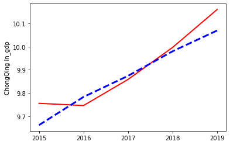

```python
##chongqing
features3=['cqln_edu','cqs','cqp']
X3 = df[features3]
y3 = df['cqln_gdp']
model = lm.fit(X3,y3)
print(model.intercept_, model.coef_)
scores = - cross_val_score(lm, X3, y3, cv=5, scoring='neg_mean_squared_error')
print(np.mean(scores))
##예측
list3=[[5.679398,76.7114,3.8914],[5.85893,73.2475,4.2738],[5.95506,80.5208,3.478],[6.038317,82.7945,4.5688],[6.108843,90.7426,4.3807]]
pred_x = pd.DataFrame(list3, columns = ['x1','x2','x3'])
print(pred_x)
pred_y = pd.DataFrame(lm.predict(pred_x), columns = ['y'])
print(pred_y)
print(type(pred_y))
result = pd.concat([pred_x, pred_y], axis = 1)
print(result)
##비교
import matplotlib.pyplot as plt
x_data = ['2015','2016','2017','2018','2019']
y_pred3 = [9.756079,9.746546,9.858961,9.996542,10.159539]
y_data3 = [9.662518,9.78361,9.874302,9.97993,10.06925]

plt.plot(x_data,y_pred3,color='red',linewidth=2.0,linestyle='-')
plt.plot(x_data,y_data3,color='blue',linewidth=3.0,linestyle='--')
plt.ylabel('ChongQing ln_gdp')
plt.show()
```

결과에 따라 충칭시에 대한 예측모형은 $$Y_{cq}=6.819+0.194X_1+0.020X_2+0.069X_3$$

그림을 보면 예측곡선과 실질 GDP곡선이 거의 비슷한 성장추세를 나왔다.

#### 3.3.4 우한시에 대한 예측과 비교

```
5.561255431213835 [0.51412873 0.0073944  0.17756678]
0.0029112420565388765
         x1       x2      x3
0  4.930285  95.6800  2.1679
1  5.159340  94.8800  2.2925
2  5.590957  94.7700  2.5528
3  5.560588  94.8800  3.2397
4  5.673996  82.7945  3.9258
          y
0  9.188499
1  9.322473
2  9.589786
3  9.696957
4  9.787727
<class 'pandas.core.frame.DataFrame'>
         x1       x2      x3         y
0  4.930285  95.6800  2.1679  9.188499
1  5.159340  94.8800  2.2925  9.322473
2  5.590957  94.7700  2.5528  9.589786
3  5.560588  94.8800  3.2397  9.696957
4  5.673996  82.7945  3.9258  9.787727
```

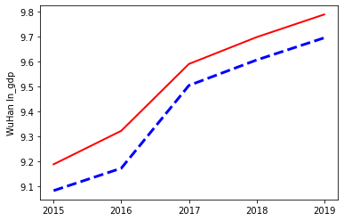

```python
##wuhan
features4=['whln_edu','whs','whp']
X4 = df[features4]
y4 = df['whln_gdp']
model = lm.fit(X4,y4)
print(model.intercept_, model.coef_)
scores = - cross_val_score(lm, X4, y4, cv=5, scoring='neg_mean_squared_error')
print(np.mean(scores))
##예측
list4=[[4.930285,95.68,2.1679],[5.15934,94.88,2.2925],[5.590957,94.77,2.5528],[5.560588,94.88,3.2397],[5.673996,82.7945,3.9258]]
pred_x = pd.DataFrame(list4, columns = ['x1','x2','x3'])
print(pred_x)
pred_y = pd.DataFrame(lm.predict(pred_x), columns = ['y'])
print(pred_y)
print(type(pred_y))
result = pd.concat([pred_x, pred_y], axis = 1)
print(result)
##비교
import matplotlib.pyplot as plt
x_data = ['2015','2016','2017','2018','2019']
y_pred4 = [9.188499,9.322473,9.589786,9.696957,9.787727]
y_data4 = [9.083193,9.172701,9.503781,9.605573,9.694185]

plt.plot(x_data,y_pred4,color='red',linewidth=2.0,linestyle='-')
plt.plot(x_data,y_data4,color='blue',linewidth=3.0,linestyle='--')
plt.ylabel('WuHan ln_gdp')
plt.show()
```

그림을 보면 오차가 0.1범위로 제어하고 거의 비슷한 성장 추세이다.

#### 3.3.5 청두시에 해한 예측과 비교

```
5.94922349399124 [0.47311204 0.00459814 0.140024  ]
0.008735500066470949
         x1       x2      x3
0  4.868697  75.5800  4.4852
1  4.930132  79.1600  4.1309
2  4.998299  81.7400  4.1088
3  5.093577  84.0300  5.7370
4  5.181397  90.7426  5.0775
          y
0  9.228226
1  9.224142
2  9.265161
3  9.548755
4  9.528824
<class 'pandas.core.frame.DataFrame'>
         x1       x2      x3         y
0  4.868697  75.5800  4.4852  9.228226
1  4.930132  79.1600  4.1309  9.224142
2  4.998299  81.7400  4.1088  9.265161
3  5.093577  84.0300  5.7370  9.548755
4  5.181397  90.7426  5.0775  9.528824
```

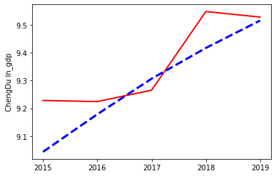

```python
##chengdu
features5=['cdln_edu','cds','cdp']
X5 = df[features5]
y5 = df['cdln_gdp']
model = lm.fit(X5,y5)
print(model.intercept_, model.coef_)
scores = - cross_val_score(lm, X5, y5, cv=5, scoring='neg_mean_squared_error')
print(np.mean(scores))
##예측
list5=[[4.868697,75.58,4.4852],[4.930132,79.16,4.1309],[4.998299,81.74,4.1088],[5.093577,84.03,5.737],[5.181397,90.7426,5.0775]]
pred_x = pd.DataFrame(list5, columns = ['x1','x2','x3'])
print(pred_x)
pred_y = pd.DataFrame(lm.predict(pred_x), columns = ['y'])
print(pred_y)
print(type(pred_y))
result = pd.concat([pred_x, pred_y], axis = 1)
print(result)
##비교
import matplotlib.pyplot as plt
x_data = ['2015','2016','2017','2018','2019']
y_pred5= [9.228226,9.224142,9.265161,9.548755,9.528824]
y_data5 = [9.043106,9.178393,9.30656,9.417406,9.516206]

plt.plot(x_data,y_pred5,color='red',linewidth=2.0,linestyle='-')
plt.plot(x_data,y_data5,color='blue',linewidth=3.0,linestyle='--')
plt.ylabel('ChengDu ln_gdp')
plt.show()
```

결과에 따라면 청두시의 예측모형은 $$Y_{cd}=5.949+0.473X_1+0.005X_2+0.140X_3$$

결과를 비교해서 예측 곡선이 청두시의 실질GDP곡선과 추세가 다른다. 2016년과 2017년에 예측결과가 실질GDP과 아주 가까운 결과를 나왔는데 다른 시점에서 차이가 많다. 다만 2019년에 비슷한 결과도 나왔다.

#### 3.3.6 정주시에 대한 예측과 비교

```
5.196597214534401 [0.25810379 0.01797573 0.71235078]
0.012658208647928968
         x1      x2      x3
0  4.578918   60.15  1.6125
1  4.605217   64.93  1.7884
2  4.713045   93.53  2.1249
3  4.889748   99.35  3.1585
4  5.099399  107.87  3.3679
           y
0   8.608339
1   8.826353
2   9.607996
3  10.494508
4  10.850939
<class 'pandas.core.frame.DataFrame'>
         x1      x2      x3          y
0  4.578918   60.15  1.6125   8.608339
1  4.605217   64.93  1.7884   8.826353
2  4.713045   93.53  2.1249   9.607996
3  4.889748   99.35  3.1585  10.494508
4  5.099399  107.87  3.3679  10.850939
```

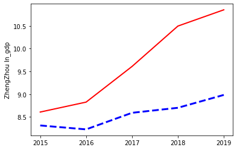

```python
##zhengzhou
features6=['zzln_edu','zzs','zzp']
X6 = df[features6]
y6 = df['zzln_gdp']
model = lm.fit(X6,y6)
print(model.intercept_, model.coef_)
scores = - cross_val_score(lm, X6, y6, cv=5, scoring='neg_mean_squared_error')
print(np.mean(scores))
##예측
list6=[[4.578918,60.15,1.6125],[4.605217,64.93,1.7884],[4.713045,93.53,2.1249],[4.889748,99.35,3.1585],[5.099399,107.87,3.3679]]
pred_x = pd.DataFrame(list6, columns = ['x1','x2','x3'])
print(pred_x)
pred_y = pd.DataFrame(lm.predict(pred_x), columns = ['y'])
print(pred_y)
print(type(pred_y))
result = pd.concat([pred_x, pred_y], axis = 1)
print(result)
##비교
import matplotlib.pyplot as plt
x_data = ['2015','2016','2017','2018','2019']
y_pred6 = [8.608339,8.826353,9.607996,10.494508,10.850939]
y_data6 = [8.313941,8.22787,8.591372,8.701668,8.983816]

plt.plot(x_data,y_pred6,color='red',linewidth=2.0,linestyle='-')
plt.plot(x_data,y_data6,color='blue',linewidth=3.0,linestyle='--')
plt.ylabel('ZhengZhou ln_gdp')
plt.show()
```

결과에 따라 정주시의 예측모형은 $$Y_{zz}=5.197+0.258X_1+0.018X_2+0.712X_3$$

예측모형의 평가결과를 보면 이 모형의 각 변수는 y과 관련도가 높으지 않고 평가결과가 다른 도시에 비해 좋지 않다. 그리고 그림을 보면 오차가 아주 크다. 그래서 정주시의 고등교육이 gdp에 영항이 다른 도시 비해 미치지 않다고 생각하다.

## 4. 결론과 정망

- 6개 도시의 예측결과를 보면 고등교육이 도시의 결제발전에 관한 상관성이 있는데 각 도시 상황에 따라 많이 다를 수도 있다.
- 전체적으로 비교하면 우한시과 충칭시의 예측결과가 실질GDP과 제일 맞추어 된다. 예측곡선의 추세도 잘 나와고 오차도 일정적인 범위에서 control를 했다. 원인은 우한시과 충칭시의 대학교 건설하는 수는 다른도시보다 많다. 우한시에서 86개 대학교가 있다. 충칭시에서 69개 대학교가 있다.
- 정부가 교유에 대해 일정적인 지출은 경제성장이 적극적으로 추진할 수 있다.